# AI/ML for Healthcare Applications : R Version Lab 4 Model Selection and Hyperparameter Tuning

Based on material from the Georgetown [Health Informatics and Data Science](https://healthinformatics.georgetown.edu) program and licensed under [CC4.0](https://creativecommons.org/licenses/by/4.0/)

The aim of this notebook is to provide an hands-on demo of selecting model and tuning hyperparameters.

## Packages

We will start by loading some of the packages that will help us organize and visualize the data. Other packages will be loaded as necessary.

```r
# Install required packages if not already installed
required_packages <- c("ggplot2", "dplyr", "caret", "e1071", "randomForest", "class", "pROC", "mlbench")

# Install missing packages
install_if_missing <- function(packages) {
  for (pkg in packages) {
    if (!require(pkg, character.only = TRUE)) {
      install.packages(pkg, dependencies = TRUE)
      library(pkg, character.only = TRUE)
    }
  }
}

install_if_missing(required_packages)

# Load required libraries
library(ggplot2)
library(dplyr)
library(caret)
library(e1071)        # For SVM
library(randomForest) # For Random Forest
library(class)        # For KNN
library(pROC)         # For ROC curves
library(mlbench)      # For datasets

# Set plot size and style
theme_set(theme_minimal())
```

## Dataset

We will be building and evaluating models to predict **diabetes** using using the diabetes dataset from the National Institute of Diabetes and Digestive and Kidney Diseases (**NIDDK**).

The objective of the dataset is to diagnostically predict whether or not a patient has diabetes, based on certain diagnostic measurements included in the dataset.

We will be using the **NIDDK diabetes dataset**, which contains 768 female patients of at least 21 years old. Fields in this dataset are:

- **Pregnancies:** Number of times pregnant
- **Glucose:** Plasma glucose concentration a 2 hours in an oral glucose tolerance test
- **BloodPressure:** Diastolic blood pressure (mm Hg)
- **SkinThickness:** Triceps skin fold thickness (mm)
- **Insulin:** 2-Hour serum insulin (mu U/ml)
- **BMI:** Body mass index (weight in kg/(height in m)^2)
- **DiabetesPedigreeFunction:** Diabetes pedigree function
- **Age:** Age (years)
- **Outcome:** Class variable (0 or 1); class value 1 is interpreted as "tested positive for diabetes"

Let's explore the dataset. You must first obtain the data file "diabetes.csv" and upload it to a directory that is accessable by this colab notebook.

```r
url <- "https://raw.githubusercontent.com/ICBI/AIMAHEAD_GU_publicCourseData/main/ML_Concepts/diabetes.csv"
destination_file <- "diabetes.csv"
```

```r
# Download the file
download.file(url, destfile = destination_file)

# Read the CSV file into a dataframe
diabetes_df <- read.csv(destination_file)
```

Check the data frame

```r
# Print the first few rows to check the data
head(diabetes_df)
```

A data.frame: 6 × 9

|  | Pregnancies <int> | Glucose <dbl> | BloodPressure <dbl> | SkinThickness <dbl> | Insulin <dbl> | BMI <dbl> | DiabetesPedigreeFunction <dbl> | Age <int> | Outcome <int> |
| --- | --- | --- | --- | --- | --- | --- | --- | --- | --- |
| 1 | 6 | 148 | 72 | 35 | NaN | 33.6 | 0.627 | 50 | 1 |
| 2 | 1 | 85 | 66 | 29 | NaN | 26.6 | 0.351 | 31 | 0 |
| 3 | 8 | 183 | 64 | NaN | NaN | 23.3 | 0.672 | 32 | 1 |
| 4 | 1 | 89 | 66 | 23 | 94 | 28.1 | 0.167 | 21 | 0 |
| 5 | 0 | 137 | 40 | 35 | 168 | 43.1 | 2.288 | 33 | 1 |
| 6 | 5 | 116 | 74 | NaN | NaN | 25.6 | 0.201 | 30 | 0 |

```r
dim(diabetes_df)
```

1. 768

2. 9

Handle missing values

```r
colSums(is.na(diabetes_df))
```

**Pregnancies**

0

**Glucose**

5

**BloodPressure**

35

**SkinThickness**

227

**Insulin**

374

**BMI**

11

**DiabetesPedigreeFunction**

0

**Age**

0

**Outcome**

0

```r
library(dplyr)
library(tidyr)

# Fill missing values in 'Pregnancies' column with 0
diabetes_df <- diabetes_df %>%
  mutate(Pregnancies = replace_na(Pregnancies, 0))
```

Replacing other missing values by median of the respective column values

```r
diabetes_df <- diabetes_df %>%
  mutate(
    Glucose = ifelse(is.na(Glucose), median(Glucose, na.rm = TRUE), Glucose),
    BloodPressure = ifelse(is.na(BloodPressure), median(BloodPressure, na.rm = TRUE), BloodPressure),
    SkinThickness = ifelse(is.na(SkinThickness), median(SkinThickness, na.rm = TRUE), SkinThickness),
    Insulin = ifelse(is.na(Insulin), median(Insulin, na.rm = TRUE), Insulin),
    BMI = ifelse(is.na(BMI), median(BMI, na.rm = TRUE), BMI)
  )
```

```r
colSums(is.na(diabetes_df))
```

**Pregnancies**

0

**Glucose**

0

**BloodPressure**

0

**SkinThickness**

0

**Insulin**

0

**BMI**

0

**DiabetesPedigreeFunction**

0

**Age**

0

**Outcome**

0

```r
table(diabetes_df$Outcome)
```

```
  0   1
500 268
```

Before we can train ML models, we have to seperate the features (`X`) and the outcome variable (`y`)

```r
X_df <- subset(diabetes_df, select = -Outcome)  # Drop the 'Outcome' column
y_df <- diabetes_df$Outcome
```

```r
dim(X_df)
length(y_df)
```

1. 768

2. 8

768

Split into train and test

```r
# Install the required package if not already installed
if (!require(caTools)) install.packages("caTools")

library(caTools)

# Split the data
set.seed(2)
split <- sample.split(y_df, SplitRatio = 0.8)

X_train <- subset(X_df, split == TRUE)
X_test <- subset(X_df, split == FALSE)
y_train <- subset(y_df, split == TRUE)
y_test <- subset(y_df, split == FALSE)
```

```r
dim(X_train)
dim(X_test)
length(y_train)
length(y_test)
```

1. 614

2. 8

1. 154

2. 8

614

154

```r
# Check the distribution of the target variable in both sets
table(y_train)
table(y_test)
```

```
y_train
  0   1
400 214
```

```
y_test
  0   1
100  54
```

## Cross-validation

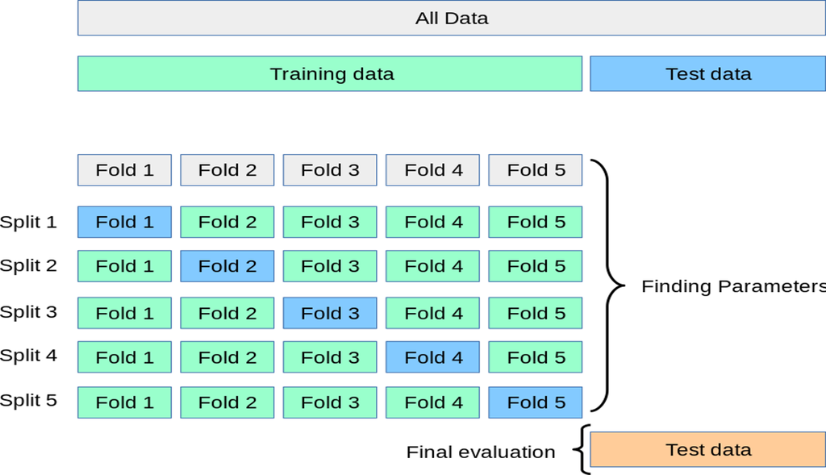

Instead of training on train set and testing on test set, we will use cross validation to evaluate a specific combination of a model and hyper parameter.

```r
# Install required packages if not already installed
if (!require(MASS)) install.packages("MASS")
library(MASS)

# Convert y_train to a factor
y_train <- as.factor(y_train)

# Combine X_train and y_train into a single dataframe
train_data <- cbind(y_train, X_train)

# Create logistic regression model
model <- glm(y_train ~ ., data = train_data, family = binomial)
```

```r
# Perform 5-fold cross-validation
set.seed(123)  # For reproducibility
cv_results <- train(y_train ~ ., data = train_data,
                    method = "glm",
                    family = binomial,
                    trControl = trainControl(method = "cv", number = 5),
                    metric = "Kappa")
```

```r
# Display the results
cv_results
```

```
Generalized Linear Model

614 samples
  8 predictor
  2 classes: '0', '1'

No pre-processing
Resampling: Cross-Validated (5 fold)
Summary of sample sizes: 492, 491, 491, 491, 491
Resampling results:

  Accuracy   Kappa
  0.7443289  0.4056018
```

```r
mean(cv_results$results$Kappa)  # Average of Kappa scores (similar to F1)
```

0.405601773647752

```r
# Make predictions on the training set
predictions_prob <- predict(model, X_test)
y_pred = ifelse (predictions_prob > 0.5, 1, 0)
# Create confusion matrix
conf_matrix <- confusionMatrix(as.factor(y_pred), as.factor(y_test))

# Extract F1 score from confusion matrix
f1_score <- (2 * conf_matrix$byClass["F1"]) / (conf_matrix$byClass["Sensitivity"] + conf_matrix$byClass["Specificity"])

# Print the F1 score
print(f1_score)
```

```
      F1
1.144408
```

```r
conf_matrix
```

```
Confusion Matrix and Statistics

          Reference
Prediction  0  1
         0 94 23
         1  6 31

               Accuracy : 0.8117
                 95% CI : (0.7409, 0.8701)
    No Information Rate : 0.6494
    P-Value [Acc > NIR] : 7.279e-06

                  Kappa : 0.5542

 Mcnemar's Test P-Value : 0.002967

            Sensitivity : 0.9400
            Specificity : 0.5741
         Pos Pred Value : 0.8034
         Neg Pred Value : 0.8378
             Prevalence : 0.6494
         Detection Rate : 0.6104
   Detection Prevalence : 0.7597
      Balanced Accuracy : 0.7570

       'Positive' Class : 0
```

```r
cm_table <- conf_matrix$table
#We use the confusion matrix function to extract the different types of errors
tn <- cm_table[1, 1]  # True negatives
fp <- cm_table[1, 2]  # False positives
fn <- cm_table[2, 1]  # False negatives
tp <- cm_table[2, 2]  # True positives

# Accuracy
accuracy <- (tp + tn) / (tp + tn + fp + fn)
cat('Accuracy: ', sprintf('%.3f', accuracy), "\n")

# Recall/Sensitivity/True Positive Rate (TPR)
recall <- tp / (tp + fn)
cat('Recall: ', sprintf('%.3f', recall), "\n")

# Precision
precision <- tp / (tp + fp)
cat('Precision: ', sprintf('%.3f', precision), "\n")

# Specificity/True Negative Rate (TNR)
specificity <- tn / (tn + fp)
cat('Specificity: ', sprintf('%.3f', specificity), "\n")

# F1 Score
f1 <- 2 * (precision * recall) / (precision + recall)
cat('F1 Score: ', sprintf('%.3f', f1), "\n")
```

```
Accuracy:  0.812
Recall:  0.838
Precision:  0.574
Specificity:  0.803
F1 Score:  0.681
```

**Different parameter**

```r
# Install required packages if not already installed
if (!require(glmnet)) install.packages("glmnet")

library(glmnet)

# Set up the control for cross-validation
train_control <- trainControl(method = "cv", number = 5)

# Train the logistic regression model with L2 regularization
# Note: glmnet requires a matrix for the features and a vector for the response
model <- train(y_train ~ .,
               data = train_data,
               method = "glmnet",
               trControl = train_control,
               tuneGrid = expand.grid(alpha = 0, lambda = 0.001))

# Get the cross-validated results
cv_results <- model$results
```

```r
cv_results
```

A data.frame: 1 × 6

|  | alpha <dbl> | lambda <dbl> | Accuracy <dbl> | Kappa <dbl> | AccuracySD <dbl> | KappaSD <dbl> |
| --- | --- | --- | --- | --- | --- | --- |
| 1 | 0 | 0.001 | 0.7427029 | 0.3954036 | 0.0287468 | 0.08813215 |

```r
mean(cv_results$Kappa)  # Average of Kappa scores (similar to F1)
```

0.395403626923314

```r
# Make predictions on the training set
predictions_prob <- predict(model, X_test)

# Create confusion matrix
conf_matrix <- confusionMatrix(as.factor(predictions_prob), as.factor(y_test))

# Extract F1 score from confusion matrix
f1_score <- (2 * conf_matrix$byClass["F1"]) / (conf_matrix$byClass["Sensitivity"] + conf_matrix$byClass["Specificity"])

# Print the F1 score
print(f1_score)
```

```
      F1
1.096924
```

```r
conf_matrix
```

```
Confusion Matrix and Statistics

          Reference
Prediction  0  1
         0 92 17
         1  8 37

               Accuracy : 0.8377
                 95% CI : (0.7698, 0.8921)
    No Information Rate : 0.6494
    P-Value [Acc > NIR] : 1.658e-07

                  Kappa : 0.6293

 Mcnemar's Test P-Value : 0.1096

            Sensitivity : 0.9200
            Specificity : 0.6852
         Pos Pred Value : 0.8440
         Neg Pred Value : 0.8222
             Prevalence : 0.6494
         Detection Rate : 0.5974
   Detection Prevalence : 0.7078
      Balanced Accuracy : 0.8026

       'Positive' Class : 0
```

```r
cm_table <- conf_matrix$table
#We use the confusion matrix function to extract the different types of errors
tn <- cm_table[1, 1]  # True negatives
fp <- cm_table[1, 2]  # False positives
fn <- cm_table[2, 1]  # False negatives
tp <- cm_table[2, 2]  # True positives

# Accuracy
accuracy <- (tp + tn) / (tp + tn + fp + fn)
cat('Accuracy: ', sprintf('%.3f', accuracy), "\n")

# Recall/Sensitivity/True Positive Rate (TPR)
recall <- tp / (tp + fn)
cat('Recall: ', sprintf('%.3f', recall), "\n")

# Precision
precision <- tp / (tp + fp)
cat('Precision: ', sprintf('%.3f', precision), "\n")

# Specificity/True Negative Rate (TNR)
specificity <- tn / (tn + fp)
cat('Specificity: ', sprintf('%.3f', specificity), "\n")

# F1 Score
f1 <- 2 * (precision * recall) / (precision + recall)
cat('F1 Score: ', sprintf('%.3f', f1), "\n")
```

```
Accuracy:  0.838
Recall:  0.822
Precision:  0.685
Specificity:  0.844
F1 Score:  0.747
```

**Different model**

```r
# Create a data frame and ensure factor levels are valid R variable names
y_train <- as.factor(y_train)
train_data <- data.frame(Outcome = y_train, X_train)
levels(train_data$Outcome) <- c("Zero", "One")
# Set up the control for cross-validation
train_control <- trainControl(method = "cv", number = 5,
                              classProbs = TRUE,
                              summaryFunction = multiClassSummary)

# Train the SVC model with a linear kernel
model <- train(Outcome ~ .,
               data = train_data,
               method = "svmLinear",
               trControl = train_control)

# Predict on training set using cross-validation
predictions <- predict(model, X_test)

y_test <- as.factor(y_test)
y_test_levels <- y_test
levels(y_test_levels) <- c("Zero","One")
# Create confusion matrix
conf_matrix <- confusionMatrix(predictions, y_test_levels)

# Extract F1 score from confusion matrix
f1_score <- conf_matrix$byClass['F1']

# Print the mean F1 score
print(mean(f1_score, na.rm = TRUE))
```

```
[1] 0.8952381
```

```r
conf_matrix
```

```
Confusion Matrix and Statistics

          Reference
Prediction Zero One
      Zero   94  16
      One     6  38

               Accuracy : 0.8571
                 95% CI : (0.7917, 0.9083)
    No Information Rate : 0.6494
    P-Value [Acc > NIR] : 6.023e-09

                  Kappa : 0.6723

 Mcnemar's Test P-Value : 0.05501

            Sensitivity : 0.9400
            Specificity : 0.7037
         Pos Pred Value : 0.8545
         Neg Pred Value : 0.8636
             Prevalence : 0.6494
         Detection Rate : 0.6104
   Detection Prevalence : 0.7143
      Balanced Accuracy : 0.8219

       'Positive' Class : Zero
```

```r
model
```

```
Support Vector Machines with Linear Kernel

614 samples
  8 predictor
  2 classes: 'Zero', 'One'

No pre-processing
Resampling: Cross-Validated (5 fold)
Summary of sample sizes: 491, 491, 492, 491, 491
Resampling results:

  logLoss    AUC        prAUC      Accuracy   Kappa      F1         Sensitivity
  0.5043821  0.8089424  0.7678354  0.7393443  0.3909279  0.8122556  0.865
  Specificity  Pos_Pred_Value  Neg_Pred_Value  Precision  Recall
  0.5043189    0.7659064       0.6659799       0.7659064  0.865
  Detection_Rate  Balanced_Accuracy
  0.5634946       0.6846595

Tuning parameter 'C' was held constant at a value of 1
```

```r
cm_table <- conf_matrix$table
#We use the confusion matrix function to extract the different types of errors
tn <- cm_table[1, 1]  # True negatives
fp <- cm_table[1, 2]  # False positives
fn <- cm_table[2, 1]  # False negatives
tp <- cm_table[2, 2]  # True positives

# Accuracy
accuracy <- (tp + tn) / (tp + tn + fp + fn)
cat('Accuracy: ', sprintf('%.3f', accuracy), "\n")

# Recall/Sensitivity/True Positive Rate (TPR)
recall <- tp / (tp + fn)
cat('Recall: ', sprintf('%.3f', recall), "\n")

# Precision
precision <- tp / (tp + fp)
cat('Precision: ', sprintf('%.3f', precision), "\n")

# Specificity/True Negative Rate (TNR)
specificity <- tn / (tn + fp)
cat('Specificity: ', sprintf('%.3f', specificity), "\n")

# F1 Score
f1 <- 2 * (precision * recall) / (precision + recall)
cat('F1 Score: ', sprintf('%.3f', f1), "\n")
```

```
Accuracy:  0.857
Recall:  0.864
Precision:  0.704
Specificity:  0.855
F1 Score:  0.776
```

SVM with non-linear kernel

```r
# Create a data frame for the training set
train_data <- data.frame(Outcome = y_train, X_train)
levels(train_data$Outcome) <- c("Zero", "One")
# Set up the control for cross-validation
train_control <- trainControl(method = "cv",
                              number = 5,
                              classProbs = TRUE,
                              summaryFunction = twoClassSummary)  # Use twoClassSummary for binary classification

# Train the SVC model with a polynomial kernel
set.seed(123)  # Setting a seed for reproducibility
model_poly <- train(Outcome ~ .,
                    data = train_data,
                    method = "svmPoly",  # Use svmPoly for polynomial kernel
                    trControl = train_control,
                    metric = "ROC")  # Change the metric to ROC for binary classification

# Print model summary
print(model_poly)

# Make predictions on the training set
predictions_poly <- predict(model_poly, X_test)

# Create confusion matrix
conf_matrix_poly <- confusionMatrix(predictions_poly, y_test_levels)

# Print confusion matrix
print(conf_matrix_poly)

# Extract F1 score from confusion matrix
f1_score_poly <- conf_matrix_poly$byClass['F1']

# Print the F1 score
print(paste("F1 Score (Polynomial Kernel):", f1_score_poly))

# Extract mean F1 score across folds
mean_f1_score_poly <- mean(model_poly$results$F1)

# Print mean F1 score
print(paste("Mean F1 Score (Polynomial Kernel):", mean_f1_score_poly))
```

```
Support Vector Machines with Polynomial Kernel

614 samples
  8 predictor
  2 classes: 'Zero', 'One'

No pre-processing
Resampling: Cross-Validated (5 fold)
Summary of sample sizes: 491, 491, 491, 492, 491
Resampling results across tuning parameters:

  degree  scale  C     ROC        Sens    Spec
  1       0.001  0.25  0.8152907  0.7925  0.6405316
  1       0.001  0.50  0.8155800  0.7875  0.6264673
  1       0.001  1.00  0.8157018  0.7900  0.6405316
  1       0.010  0.25  0.8157004  0.7850  0.6451827
  1       0.010  0.50  0.8154097  0.8075  0.5985604
  1       0.010  1.00  0.8201758  0.8625  0.5235880
  1       0.100  0.25  0.8174903  0.8725  0.5096346
  1       0.100  0.50  0.8167885  0.8800  0.4956811
  1       0.100  1.00  0.8158361  0.8825  0.4817276
  2       0.001  0.25  0.8156437  0.7925  0.6405316
  2       0.001  0.50  0.8155842  0.7950  0.6358804
  2       0.001  1.00  0.8155842  0.7850  0.6498339
  2       0.010  0.25  0.8164632  0.8225  0.5890365
  2       0.010  0.50  0.8204665  0.8650  0.5328904
  2       0.010  1.00  0.8202229  0.8750  0.5049834
  2       0.100  0.25  0.8256880  0.8925  0.4770764
  2       0.100  0.50  0.8199059  0.8850  0.4817276
  2       0.100  1.00  0.8124308  0.8875  0.4487265
  3       0.001  0.25  0.8155246  0.7950  0.6451827
  3       0.001  0.50  0.8154651  0.7925  0.6358804
  3       0.001  1.00  0.8154665  0.7900  0.6312292
  3       0.010  0.25  0.8219366  0.8550  0.5471761
  3       0.010  0.50  0.8222771  0.8700  0.5235880
  3       0.010  1.00  0.8227519  0.8775  0.5049834
  3       0.100  0.25  0.8183499  0.8875  0.4765227
  3       0.100  0.50  0.8111365  0.8900  0.4767442
  3       0.100  1.00  0.8024502  0.8975  0.4299003

```

[output cut: 15 more lines]

```

 Mcnemar's Test P-Value : 0.03764

            Sensitivity : 0.9200
            Specificity : 0.6296
         Pos Pred Value : 0.8214
         Neg Pred Value : 0.8095
             Prevalence : 0.6494
         Detection Rate : 0.5974
   Detection Prevalence : 0.7273
      Balanced Accuracy : 0.7748

       'Positive' Class : Zero

[1] "F1 Score (Polynomial Kernel): 0.867924528301887"
```

```
[1] "Mean F1 Score (Polynomial Kernel): NA"
```

```r
cm_table <- conf_matrix_poly$table
#We use the confusion matrix function to extract the different types of errors
tn <- cm_table[1, 1]  # True negatives
fp <- cm_table[1, 2]  # False positives
fn <- cm_table[2, 1]  # False negatives
tp <- cm_table[2, 2]  # True positives

# Accuracy
accuracy <- (tp + tn) / (tp + tn + fp + fn)
cat('Accuracy: ', sprintf('%.3f', accuracy), "\n")

# Recall/Sensitivity/True Positive Rate (TPR)
recall <- tp / (tp + fn)
cat('Recall: ', sprintf('%.3f', recall), "\n")

# Precision
precision <- tp / (tp + fp)
cat('Precision: ', sprintf('%.3f', precision), "\n")

# Specificity/True Negative Rate (TNR)
specificity <- tn / (tn + fp)
cat('Specificity: ', sprintf('%.3f', specificity), "\n")

# F1 Score
f1 <- 2 * (precision * recall) / (precision + recall)
cat('F1 Score: ', sprintf('%.3f', f1), "\n")
```

```
Accuracy:  0.818
Recall:  0.810
Precision:  0.630
Specificity:  0.821
F1 Score:  0.708
```

Helper function to train and return results on test set

```r
# Function to train and test the model
train_and_test <- function(model, X_train, y_train, X_test, y_test) {
  # Combine training data into a data frame
  train_data <- data.frame(Outcome = as.factor(y_train), X_train)

  # Fit the model
  model_fit <- train(Outcome ~ ., data = train_data, method = model)

  # Combine test data into a data frame
  test_data <- data.frame(X_test)

  # Predict using the fitted model
  y_test_pred <- predict(model_fit, test_data)

  # Print classification report (confusion matrix and metrics)
  conf_matrix <- confusionMatrix(y_test_pred, as.factor(y_test))
  print(conf_matrix)

  cm_table <- conf_matrix$table
#We use the confusion matrix function to extract the different types of errors
  tn <- cm_table[1, 1]  # True negatives
  fp <- cm_table[1, 2]  # False positives
  fn <- cm_table[2, 1]  # False negatives
  tp <- cm_table[2, 2]  # True positives

# Accuracy
  accuracy <- (tp + tn) / (tp + tn + fp + fn)
  cat('Accuracy: ', sprintf('%.3f', accuracy), "\n")

# Recall/Sensitivity/True Positive Rate (TPR)
  recall <- tp / (tp + fn)
  cat('Recall: ', sprintf('%.3f', recall), "\n")

# Precision
  precision <- tp / (tp + fp)
  cat('Precision: ', sprintf('%.3f', precision), "\n")

# Specificity/True Negative Rate (TNR)
  specificity <- tn / (tn + fp)
  cat('Specificity: ', sprintf('%.3f', specificity), "\n")

# F1 Score
  f1 <- 2 * (precision * recall) / (precision + recall)
  cat('F1 Score: ', sprintf('%.3f', f1), "\n")
}
```

Fit best model and deploy

```r
# Define the model (Logistic Regression)
best_model <- "glm"  # For Logistic Regression, use method = "glm" in train()
```

```r
# Train and test the model
train_and_test(best_model, X_train, y_train, X_test, y_test)
```

```
Confusion Matrix and Statistics

          Reference
Prediction  0  1
         0 92 14
         1  8 40

               Accuracy : 0.8571
                 95% CI : (0.7917, 0.9083)
    No Information Rate : 0.6494
    P-Value [Acc > NIR] : 6.023e-09

                  Kappa : 0.6781

 Mcnemar's Test P-Value : 0.2864

            Sensitivity : 0.9200
            Specificity : 0.7407
         Pos Pred Value : 0.8679
         Neg Pred Value : 0.8333
             Prevalence : 0.6494
         Detection Rate : 0.5974
   Detection Prevalence : 0.6883
      Balanced Accuracy : 0.8304

       'Positive' Class : 0

Accuracy:  0.857
Recall:  0.833
Precision:  0.741
Specificity:  0.868
F1 Score:  0.784
```

## Grid Search

```r
# Set up the grid of hyperparameters
tune_grid <- expand.grid(
  alpha = 1, # Lasso (L1) or Ridge (L2) regularization (glmnet uses 'alpha')
  lambda = c(1, 10)  # Equivalent to 'C' in sklearn
)
```

Define model and a set of parameters for the model

```r
# Define cross-validation control
train_control <- trainControl(
  method = "cv",  # Cross-validation
  number = 5,     # Number of folds
  summaryFunction = defaultSummary  # Use F1 scoring for evaluation
)

train_data_0 <- data.frame(Outcome = y_train, X_train)
# Define and train the model
model <- train(
  Outcome ~ .,               # Outcome variable
  data = train_data_0,         # Training data frame
  method = "glmnet",         # Use 'glmnet' for logistic regression with regularization
  trControl = train_control, # Cross-validation control
  tuneGrid = tune_grid       # Parameter grid for tuning
)
```

Grid search returns an instance of the model with best combination parameters

```r
# Show the cross-validation results
print(model$results)
```

```
  alpha lambda  Accuracy Kappa  AccuracySD KappaSD
1     1      1 0.6514727     0 0.002384186       0
2     1     10 0.6514727     0 0.002384186       0
```

```r
# Show the best hyperparameters
print(model$bestTune) #alpha is penalty, lambda is similar to C
```

```
  alpha lambda
2     1     10
```

Best parameters

```r
# Get the row that matches best parameters in model$results
best_row <- with(model$results,
                 which(alpha == model$bestTune$alpha & lambda == model$bestTune$lambda))

# Display the best row
print(model$results[best_row, ])
```

```
  alpha lambda  Accuracy Kappa  AccuracySD KappaSD
2     1     10 0.6514727     0 0.002384186       0
```

No need to fit the a model with best param on training set; Grid search returns an instance of the model with best combination parameters

```r
# Use the fitted model to predict on the test set
y_test_pred <- predict(model, X_test)

# Get the confusion matrix to calculate metrics
conf_matrix <- confusionMatrix(data = y_test_pred, reference = y_test, positive = "1")

# Print the classification report
classification_report <- data.frame(
  Metric = c("Precision", "Recall", "F1-Score", "Support"),
  Value = c(conf_matrix$byClass["Precision"],
            conf_matrix$byClass["Recall"],
            conf_matrix$byClass["F1"],
            sum(conf_matrix$table))
)

print(classification_report)
```

```
             Metric Value
Precision Precision    NA
Recall       Recall     0
F1         F1-Score    NA
            Support   154
```

```r
conf_matrix
```

```
Confusion Matrix and Statistics

          Reference
Prediction   0   1
         0 100  54
         1   0   0

               Accuracy : 0.6494
                 95% CI : (0.5684, 0.7244)
    No Information Rate : 0.6494
    P-Value [Acc > NIR] : 0.537

                  Kappa : 0

 Mcnemar's Test P-Value : 5.498e-13

            Sensitivity : 0.0000
            Specificity : 1.0000
         Pos Pred Value :    NaN
         Neg Pred Value : 0.6494
             Prevalence : 0.3506
         Detection Rate : 0.0000
   Detection Prevalence : 0.0000
      Balanced Accuracy : 0.5000

       'Positive' Class : 1
```

**Iterating through several models and selecting hyperparameter for each**

At the end we will output the best model

```r
train_and_dump_best_model <- function(X_train, y_train) {
  # Convert outcome variable to a factor (if not already)
  y_train <- as.factor(y_train)

  # Create a data frame with predictors and outcome variable
  train_data <- data.frame(Outcome = y_train, X_train)
  colnames(train_data)[1] <- "Outcome"  # Rename the outcome variable to "Outcome"
  levels(train_data$Outcome) <- c("Zero", "One")

  # Define parameter grids for each model
  param_grid_lr <- expand.grid(
    alpha = c(1, 0),          # 1 for L1 (lasso), 0 for L2 (ridge)
    lambda = c(1.0, 0.5, 0.1) # Corresponding to C parameter inversely
  )

  param_grid_svm <- expand.grid(
    C = c(1, 5, 10)           # Regularization parameter for SVM
  )

  param_grid_rf <- expand.grid(
    mtry = c(1, 3, 5)         # Number of variables randomly sampled as candidates at each split
  )

  # Define control for cross-validation
  train_control <- trainControl(method = "cv", number = 5, classProbs = TRUE, summaryFunction = twoClassSummary)

  # Set up model training pipelines
  models <- list(
    LogisticRegression = train(
      Outcome ~ ., data = train_data, method = "glmnet",
      tuneGrid = param_grid_lr, trControl = train_control, metric = "ROC"
    ),
    SVM = train(
      Outcome ~ ., data = train_data, method = "svmLinear",
      tuneGrid = param_grid_svm, trControl = train_control, metric = "ROC"
    ),
    RandomForest = train(
      Outcome ~ ., data = train_data, method = "rf",
      tuneGrid = param_grid_rf, trControl = train_control, metric = "ROC"
    )
  )

  # Evaluate the best model
  best_model <- NULL
  best_score <- -Inf
  best_name <- NULL

  for (name in names(models)) {
    model <- models[[name]]
    score <- max(model$results$ROC, na.rm = TRUE)
    if (score > best_score) {
      best_score <- score
      best_model <- model
      best_name <- name
    }
  }

  print(paste("Best Model:", best_name))
  print(best_model$bestTune)

  return(best_model)
}
```

```r
# Train and identify the best model
best_model_gs <- train_and_dump_best_model(X_train, y_train)
```

```
[1] "Best Model: SVM"
  C
1 1
```

```r
# Use the best model to predict on the test set
y_test_pred <- predict(best_model_gs, X_test)

# Print classification report
conf_matrix <- confusionMatrix(y_test_pred, y_test_levels, positive = "One")
classification_report <- data.frame(
  Metric = c("Precision", "Recall", "F1-Score", "Support"),
  Value = c(conf_matrix$byClass["Precision"],
            conf_matrix$byClass["Recall"],
            conf_matrix$byClass["F1"],
            sum(conf_matrix$table))
)

print(classification_report)
```

```
             Metric       Value
Precision Precision   0.8636364
Recall       Recall   0.7037037
F1         F1-Score   0.7755102
            Support 154.0000000
```

```r
conf_matrix
```

```
Confusion Matrix and Statistics

          Reference
Prediction Zero One
      Zero   94  16
      One     6  38

               Accuracy : 0.8571
                 95% CI : (0.7917, 0.9083)
    No Information Rate : 0.6494
    P-Value [Acc > NIR] : 6.023e-09

                  Kappa : 0.6723

 Mcnemar's Test P-Value : 0.05501

            Sensitivity : 0.7037
            Specificity : 0.9400
         Pos Pred Value : 0.8636
         Neg Pred Value : 0.8545
             Prevalence : 0.3506
         Detection Rate : 0.2468
   Detection Prevalence : 0.2857
      Balanced Accuracy : 0.8219

       'Positive' Class : One
```

**The END**  
**Authors: Dr. Samir Gupta, Dr. Matthew McCoy, Jia Li Dong (M.S.) & ICBI AIM-AHEAD Team**